# Atividade_Avaliativa

2024-05-23

## Importando e entendendo os dados

Leitura e etendimento dos dados e vizualização das primeiras linhas.

```r
library(readxl)
dados_exercio <- read.csv("/home/beatriz-pessoal/Downloads/dados_exercio.csv")
str(dados_exercio)
```

```
## 'data.frame':    374 obs. of  13 variables:
##  $ Person.ID              : int  1 2 3 4 5 6 7 8 9 10 ...
##  $ Gender                 : chr  "Male" "Male" "Male" "Male" ...
##  $ Age                    : int  27 28 28 28 28 28 29 29 29 29 ...
##  $ Occupation             : chr  "Software Engineer" "Doctor" "Doctor" "Sales Representative" ...
##  $ Sleep.Duration         : num  6.1 6.2 6.2 5.9 5.9 5.9 6.3 7.8 7.8 7.8 ...
##  $ Quality.of.Sleep       : int  6 6 6 4 4 4 6 7 7 7 ...
##  $ Physical.Activity.Level: int  42 60 60 30 30 30 40 75 75 75 ...
##  $ Stress.Level           : int  6 8 8 8 8 8 7 6 6 6 ...
##  $ BMI.Category           : chr  "Overweight" "Normal" "Normal" "Obese" ...
##  $ Blood.Pressure         : chr  "126/83" "125/80" "125/80" "140/90" ...
##  $ Heart.Rate             : int  77 75 75 85 85 85 82 70 70 70 ...
##  $ Daily.Steps            : int  4200 10000 10000 3000 3000 3000 3500 8000 8000 8000 ...
##  $ Sleep.Disorder         : chr  "None" "None" "None" "Sleep Apnea" ...
```

```r
head(dados_exercio)
```

```
##   Person.ID Gender Age           Occupation Sleep.Duration Quality.of.Sleep
## 1         1   Male  27    Software Engineer            6.1                6
## 2         2   Male  28               Doctor            6.2                6
## 3         3   Male  28               Doctor            6.2                6
## 4         4   Male  28 Sales Representative            5.9                4
## 5         5   Male  28 Sales Representative            5.9                4
## 6         6   Male  28    Software Engineer            5.9                4
##   Physical.Activity.Level Stress.Level BMI.Category Blood.Pressure Heart.Rate
## 1                      42            6   Overweight         126/83         77
## 2                      60            8       Normal         125/80         75
## 3                      60            8       Normal         125/80         75
## 4                      30            8        Obese         140/90         85
## 5                      30            8        Obese         140/90         85
## 6                      30            8        Obese         140/90         85
##   Daily.Steps Sleep.Disorder
## 1        4200           None
## 2       10000           None
## 3       10000           None
## 4        3000    Sleep Apnea
## 5        3000    Sleep Apnea
## 6        3000       Insomnia
```

O data set exibe alguns dados que foram coletados de pessoas, tais como gênero, idade, profissão e informações sobre qualidade do sono e atividade física. Através do summary já podemos observar algumas informações relevantes, por exemplo, a média de idade dos participantes da pesquisa é de 42 anos, a média de horas de sono é de 7 horas e a média de minutos de atividade física é de 59 minutos.

```r
summary(dados_exercio)
```

```
##    Person.ID         Gender               Age         Occupation
##  Min.   :  1.00   Length:374         Min.   :27.00   Length:374
##  1st Qu.: 94.25   Class :character   1st Qu.:35.25   Class :character
##  Median :187.50   Mode  :character   Median :43.00   Mode  :character
##  Mean   :187.50                      Mean   :42.18
##  3rd Qu.:280.75                      3rd Qu.:50.00
##  Max.   :374.00                      Max.   :59.00
##  Sleep.Duration  Quality.of.Sleep Physical.Activity.Level  Stress.Level
##  Min.   :5.800   Min.   :4.000    Min.   :30.00           Min.   :3.000
##  1st Qu.:6.400   1st Qu.:6.000    1st Qu.:45.00           1st Qu.:4.000
##  Median :7.200   Median :7.000    Median :60.00           Median :5.000
##  Mean   :7.132   Mean   :7.313    Mean   :59.17           Mean   :5.385
##  3rd Qu.:7.800   3rd Qu.:8.000    3rd Qu.:75.00           3rd Qu.:7.000
##  Max.   :8.500   Max.   :9.000    Max.   :90.00           Max.   :8.000
##  BMI.Category       Blood.Pressure       Heart.Rate     Daily.Steps
##  Length:374         Length:374         Min.   :65.00   Min.   : 3000
##  Class :character   Class :character   1st Qu.:68.00   1st Qu.: 5600
##  Mode  :character   Mode  :character   Median :70.00   Median : 7000
##                                        Mean   :70.17   Mean   : 6817
##                                        3rd Qu.:72.00   3rd Qu.: 8000
##                                        Max.   :86.00   Max.   :10000
##  Sleep.Disorder
##  Length:374
##  Class :character
##  Mode  :character
##
##
##
```

## Análise univariável

### Variáveis qualitativas

A leitura abaixo utiliza a variável “Gender” e através disso podemos observar que a distribuição é muito semelhante entre os gêneros, sendo que 49,5% dos participantes da pesquisa são do gênero feminino e 50,5% do gênero masculino.

```r
gender_percentage <- round(prop.table(table(dados_exercio$Gender)) * 100, 1)
gender_percentage
```

```
##
## Female   Male
##   49.5   50.5
```

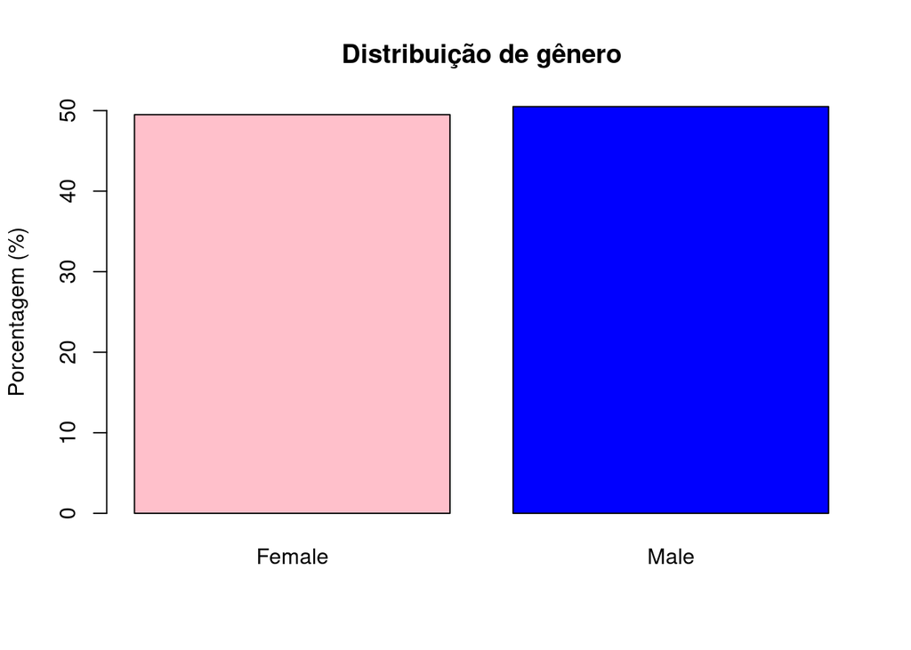

```r
barplot(gender_percentage,
    col = c("pink", "blue"),
    main = "Distribuição de gênero",
    ylab = "Porcentagem (%)"
)
```

Abaixo podemos observar a distribuição das profissões dos participantes da pesquisa, onde a profissão mais comum é a de “Nurse” com 19,5% dos participantes, seguida por “Doctor” com 19% e “Engineer” com 16,8%.

```r
occupation_percentage <- sort(round(prop.table(table(dados_exercio$Occupation)) * 100, 1), decreasing = T)
occupation_percentage
```

```
##
##                Nurse               Doctor             Engineer
##                 19.5                 19.0                 16.8
##               Lawyer              Teacher           Accountant
##                 12.6                 10.7                  9.9
##          Salesperson            Scientist    Software Engineer
##                  8.6                  1.1                  1.1
## Sales Representative              Manager
##                  0.5                  0.3
```

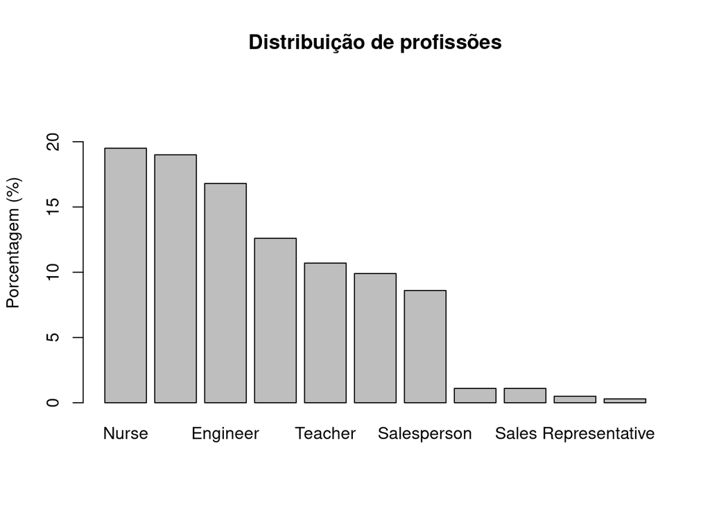

```r
barplot(occupation_percentage,
    main = "Distribuição de profissões",
    ylab = "Porcentagem (%)",
    ylim = c(0, max(occupation_percentage) + 5)
)
```

### Variáveis quantitativas

#### Qualidade de sono

A seguir observa-se a distribuição de qualidade de sono das pessoas. Nota-se que 48,1% dos participantes da pesquisa tem qualidade de sono igual a 8 ou 9.

```r
sleep_quality <- round(prop.table(table(dados_exercio$Quality.of.Sleep)) * 100, 1)
sum(sleep_quality[c("8", "9")])
```

```
## [1] 48.1
```

E a distribuição geral da qualidade de sono pode ser observada no grafico abaixo.

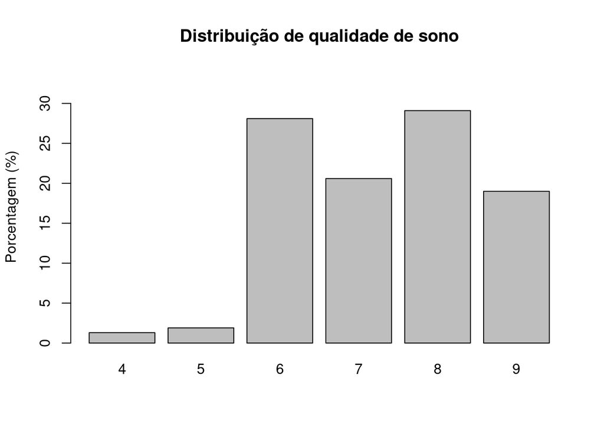

```r
barplot(sleep_quality,
    main = "Distribuição de qualidade de sono",
    ylab = "Porcentagem (%)",
    ylim = c(0, max(sleep_quality) + 5)
)
```

#### Duração de sono

Em seguida, observa-se a distribuição de duração de sono das pessoas. Nota-se que 50% dos participantes da pesquisa tem noites de sono com duração de até 7,2 horas.

```r
quantile(dados_exercio$Sleep.Duration)
```

```
##   0%  25%  50%  75% 100%
##  5.8  6.4  7.2  7.8  8.5
```

Dessa forma temos que a mediana é igual a 7,2 e a média é igual a 7.

```r
median(dados_exercio$Sleep.Duration)
```

```
## [1] 7.2
```

```r
mean(dados_exercio$Sleep.Duration)
```

```
## [1] 7.132086
```

O boxplot nos ilustra a distribuição de horas de sono dos participantes da pesquisa, observa-se que há uma distribuição simétrica e que não há outliers.

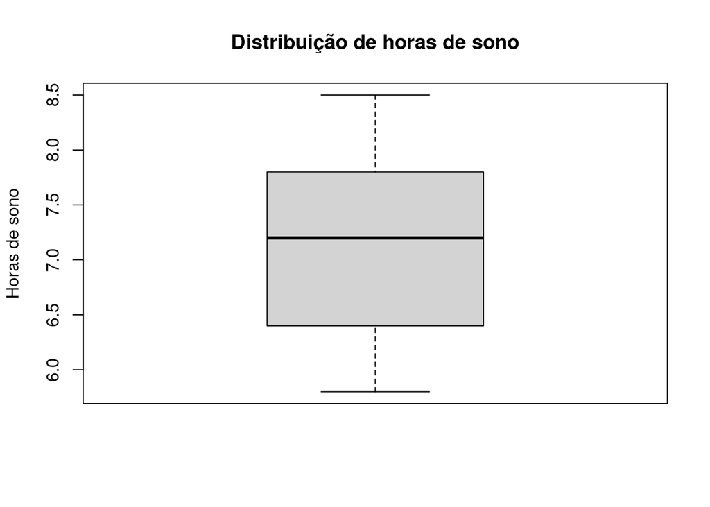

```r
boxplot(dados_exercio$Sleep.Duration,
    main = "Distribuição de horas de sono",
    ylab = "Horas de sono"
)
```

#### Tempo de atividade física

A seguir, observa-se a distribuição de minutos de atividade física das pessoas. Nota-se que 50% dos participantes da pesquisa tem minutos de atividade física de até 60 minutos por dia.

```r
quantile(dados_exercio$Physical.Activity)
```

```
##   0%  25%  50%  75% 100%
##   30   45   60   75   90
```

Abaixo temos que a mediana é igual a 60 e a média é igual a 59,1, sendo as duas medidas muito próximas entre si.

```r
median(dados_exercio$Physical.Activity)
```

```
## [1] 60
```

```r
mean(dados_exercio$Physical.Activity)
```

```
## [1] 59.17112
```

O boxplot nos ilustra a distribuição de minutos de atividade física dos participantes da pesquisa, observa-se que há uma distribuição simétrica e que não há outliers.

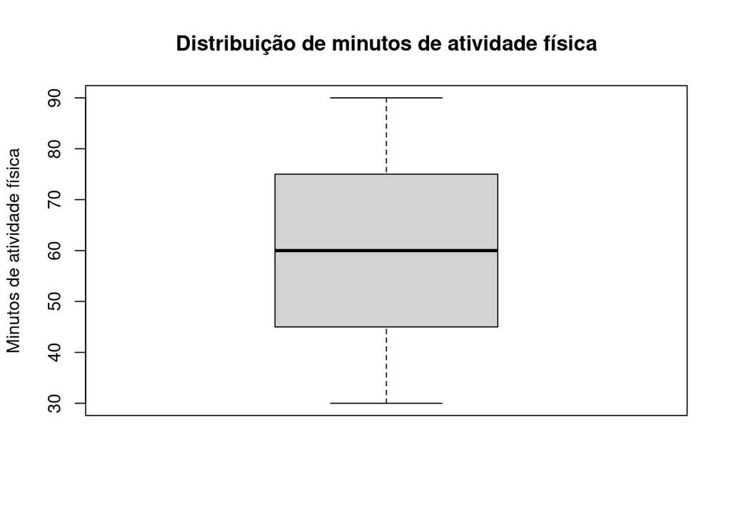

```r
boxplot(dados_exercio$Physical.Activity,
    main = "Distribuição de minutos de atividade física",
    ylab = "Minutos de atividade física"
)
```

## Análise entre duas variáveis

### Relações entre variáveis qualitativas

#### Gênero e profissão

Através da tabela abaixo, podemos observar que a profissão mais comum entre os homens é “Doctor” com 18,4% dos participantes, enquanto que entre as mulheres é “Nurse” com 19,5% dos participantes.

```r
addmargins(round(prop.table(table(dados_exercio$Gender, dados_exercio$Occupation)) * 100, 1))
```

```
##
##          Accountant Doctor Engineer Lawyer Manager Nurse Sales Representative
##   Female        9.6    0.5      8.6    0.5     0.3  19.5                  0.0
##   Male          0.3   18.4      8.3   12.0     0.0   0.0                  0.5
##   Sum           9.9   18.9     16.9   12.5     0.3  19.5                  0.5
##
##          Salesperson Scientist Software Engineer Teacher   Sum
##   Female         0.0       1.1               0.0     9.4  49.5
##   Male           8.6       0.0               1.1     1.3  50.5
##   Sum            8.6       1.1               1.1    10.7 100.0
```

### Relação entre variáveis quantitativas

#### Qualidade de sono e duração de sono

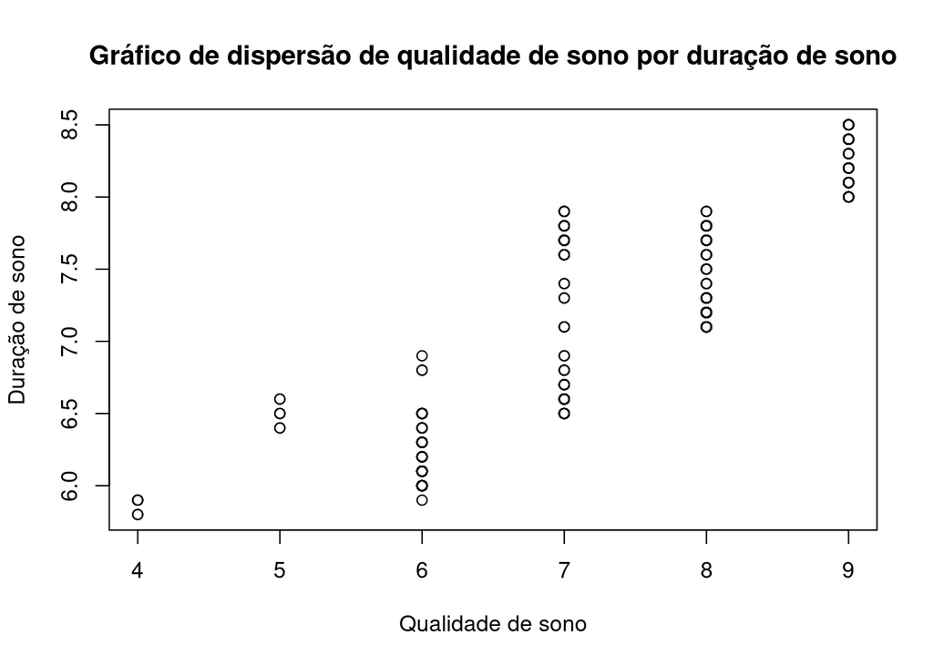

```r
plot(dados_exercio$Quality.of.Sleep, dados_exercio$Sleep.Duration,
    xlab = "Qualidade de sono",
    ylab = "Duração de sono",
    main = "Gráfico de dispersão de qualidade de sono por duração de sono"
)
```

### Relação entre variáveis qualitativas com quantitativas

#### Qualidade de sono por gênero

Através do boxplot abaixo podemos observar que a qualidade de sono é um pouco melhor entre as mulheres do que entre os homens.

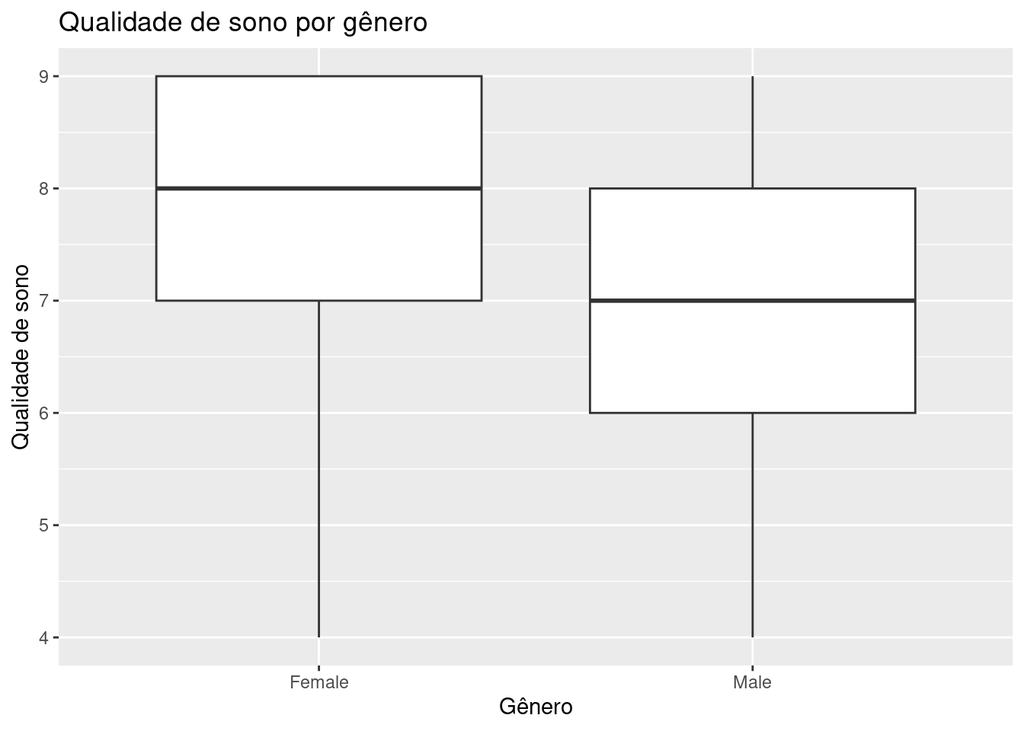

```r
require(ggplot2)

ggplot(data = dados_exercio, aes(y = Quality.of.Sleep, x = Gender)) +
    geom_boxplot() +
    labs(title = "Qualidade de sono por gênero", y = "Qualidade de sono", x = "Gênero")
```